# Lab 3: Mine Crafting

As with previous labs, be sure to submit only the `lab3.ipynb` and `lab3.html` version of the lab in your github `Lab3` folder. No more, and no less.

## Introduction

Imagine you are a scientist for a mining company that operates a vertical mine at the Earth's equator. This is one of the deepest mines on Earth; it's roughly 4 km to the bottom of the shaft. Your boss proposes to measure the vertical depth of the shaft by dropping a 1 kg test mass and accurately measuring the time to hit the bottom.

You will be guided in your investigations below and submit your report in the form of this notebook. Be sure to be quantitative in nature, produce highly polished plots, with appropriate titles, units, etc.

A table of relevant physical constants is below. Good luck!

| Quantity | Value |
| --- | --- |
| Gravitational Constant ($G$) | $6.6743 \times 10^{-11}$ m$^3$/kg/s$^2$ |
| Gravitational Acceleration ($g_o$) | 9.81 m/s$^2$ (approximate) |
| Mass of the Earth ($M_{\oplus}$) | $5.972 \times 10^{24}$ kg |
| Mass of the Moon ($M_{m}$) | $7.35 \times 10^{22}$ kg |
| Radius of the Earth ($R_{\oplus}$) | 6378.1 km |
| Radius of the Moon ($R_{m}$) | 1738.1 km |
| Earth's Rotation Rate at the Equator | $7.272 \times 10^{-5} $ rad/s |

## Part 1: The Ideal Case

In this section and the following sections, we calculate the time for the 1 kg test mass to reach the bottom of the mineshaft under a series of increasingly complex assumptions. Remember that a projectile experiencing a constant gravitational force, plus a drag force, obeys the following second order differential equation:

$$ \frac{d^2y}{dt^2} = -g + \alpha \left| \frac{dy}{dt} \right|^{\gamma} \tag{1} $$

where $t$ is time, $y$ is the height, $g$ is the gravitational acceleration, $\alpha$ is the drag coefficient, and $\gamma$ is the speed dependence of the drag. For example, for $\gamma=2$, the drag force grows proportionally to the speed *squared*. **Hint**: pay particular attention to the sign conventions in your implementation! The drag, by definition, should *oppose* the direction of motion.

1. First, make a simple calculation of how long a test mass would take to reach the bottom of the 4km shaft assuming no drag. This is the simple free-fall algebraic expression you know from PHYS 171.
2. Next, reduce (1) into a *system* of coupled first order differential equations by setting the velocity $v = dy/dt$.
3. Numerically solve (1) using `solve_ivp` assuming $\alpha=0$. Plot the position and velocity as a function of time.  
   Draw a horizontal dashed line at the depth of the bottom of the shaft, to make it easy to see. Make the plot look nice, including displaying the position on the left axes, and plotting the velocity on a second right axis, using matplotlib `twinx` capability.  
   In your notebook, label this figure clearly as **Figure 1**.
4. Using the `events` detection capability of `solve_ivp`, calculate the time at which the mass hits the bottom of the shaft in the case of zero drag ($\alpha=0$). Compare this to your analytic calculation and discuss any differences you might see.

```python
import numpy as np
import matplotlib.pyplot as plt
from scipy.integrate import solve_ivp, quad
```

```python
# Constants
G = 6.6743e-11 # m^3/kg/s^2
g0 = 9.81 # m/s^2
M_earth = 5.972e24 # kg
M_moon = 7.35e22 #kg
R_earth = 6378.1e3 # m
R_moon = 1738.1e3 # m
omega = 7.272e-5 # rad/s
```

```
Simple calculated time: 28.6 s
Numeric time to hit bottom (no drag): 28.6 s
```

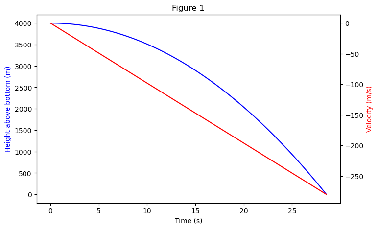

```python
shaft_depth = 4000.0 # m
simple_calc_t = np.sqrt(2 * shaft_depth / g0)
print(f"Simple calculated time: {simple_calc_t:.3} s")

def ode_ideal(t, S):
    y, v = S
    return [v, -g0]

# Event to stop at the bottom of the 4km shaft
def hit_bottom(t, S):
    return S[0] - (R_earth - shaft_depth)
hit_bottom.terminal = True
hit_bottom.direction = -1

sol_ideal = solve_ivp(ode_ideal, [0, 100], [R_earth, 0], events=hit_bottom, dense_output=True)
t_hit = sol_ideal.t_events[0][0]
print(f"Numeric time to hit bottom (no drag): {t_hit:.3} s")

fig1, ax1 = plt.subplots(figsize=(8, 5))
ax2 = ax1.twinx()
t_plot = np.linspace(0, t_hit, 100)
y_plot, v_plot = sol_ideal.sol(t_plot)

# Plot height relative to the bottom of the shaft
ax1.plot(t_plot, y_plot - (R_earth - shaft_depth), 'blue', label='Height')
ax2.plot(t_plot, v_plot, 'red', label='Velocity')

ax1.set_xlabel('Time (s)')
ax1.set_ylabel('Height above bottom (m)', color='blue')
ax2.set_ylabel('Velocity (m/s)', color='red')
plt.title('Figure 1')
```

## Part 2: Including Drag and a Variable g

In practice, we cannot ignore drag, and we should also not assume that $g$ is a constant. If you approximate that the mass of the Earth is distributed homogenously (which it is not!), then the gravitational constant $g$ will depend on your distance $r$ from the center of the Earth in a simple linear way:

$$ g(r) = g_o \left( \frac{r}{R_{\oplus}} \right) \tag{2} $$

where $g_o$ is the gravity at the surface, and $R_{\oplus}$ is the radius of the Earth.

1. Make a new plot that shows the velocity and position as a function of  
   time assuming $g(y)$. Be careful with coordinate systems! The test mass' position should be at the Earth radius at $t=0$, and falling down. But for plotting purposes, it will be useful to plot the height above the bottom of the shaft.  
   In your notebook, label this figure clearly as **Figure 2**.
2. What effect does incorporating a height-dependent $g$ have on the fall time? Explain.
3. Now, turn on drag, and replot the position and velocity. For most things, $\gamma=2$ is a good assumption. How can you calibrate the value of $\alpha$? Think about what we did in Lecture 15/16, where we assumed a sky-diver's terminal speed was 50 m/s. You should assume the same of the test mass. What affect does including drag have on the fall time?

```
Time to hit bottom: 83.5 s
```

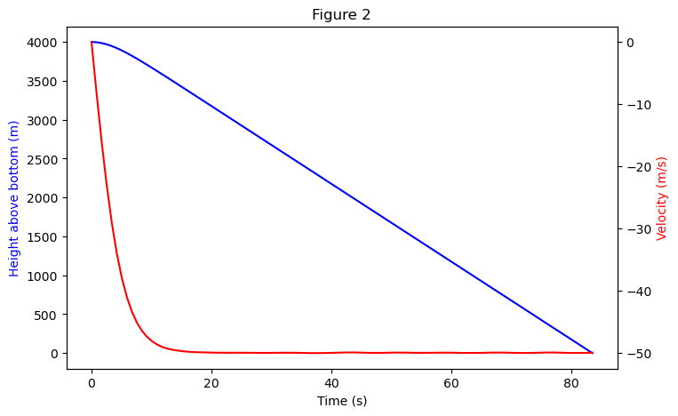

```python
v_term = 50.0 # assume terminal speed
alpha = g0 / (v_term**2)

def ode_drag_var_g(t, S):
    y, v = S
    g_local = g0 * (y / R_earth)
    # Drag opposes velocity
    drag = alpha * np.abs(v)**2 * (-np.sign(v))
    return [v, -g_local + drag]

sol_drag = solve_ivp(ode_drag_var_g, [0, 200], [R_earth, 0], events=hit_bottom, dense_output=True)
t_hit_drag = sol_drag.t_events[0][0]
print(f"Time to hit bottom: {t_hit_drag:.3} s")

fig2, ax1 = plt.subplots(figsize=(8, 5))
ax2 = ax1.twinx()
t_plot = np.linspace(0, t_hit_drag, 100)
y_plot, v_plot = sol_drag.sol(t_plot)

ax1.plot(t_plot, y_plot - (R_earth - shaft_depth), 'blue')
ax2.plot(t_plot, v_plot, 'red')

ax1.set_xlabel('Time (s)')
ax1.set_ylabel('Height above bottom (m)', color='blue')
ax2.set_ylabel('Velocity (m/s)', color='red')
plt.title('Figure 2')
```

## Part 3: The Coriolis Force

Since the Earth is rotating, there is a Coriolis force on the test mass as it falls. The force can be quite large. For example, imagine the mine shaft is on the Earth's equator and pointed towards the Earth's center. The equator rotates at about half a kilometer per second. So once the test mass has fallen for some time, it will bump into the wall, unless the shaft is very wide. The Coriolis force $\vec{F_c}$ is:

$$ \vec{F_c} = -2m \, \left( \vec{\Omega} \times \vec{v} \right) \tag{3} $$

where $\vec{\Omega}$ is the Earth's rotation rate for a vector along $\hat{z}$ and $m$ is the mass of the object (1 kg for the test mass in this case). For a mine shaft on the equator, we might pick a right-handed coordinate system with the $\hat{x}$ axis along the East, $\hat{y}$ down into the mine shaft, and $\hat{z}$ along the North. This implies the component of the force are:

\begin{equation} F_{c_x} = + 2m \, \Omega v_y \tag{4} \end{equation} \begin{equation} F_{c_y} = - 2m \, \Omega v_x \tag{5} \end{equation} \begin{equation} F_{c_z} = 0 \tag{6} \end{equation}

1. Extend and update your differential equations of motion to include the Coriolis force. You will need to add a Coriolis acceleration term to your equation for the depth coordinate (remember, $F=ma$), and additionally, start tracking the velocity and position in the transverse direction (``side-to-side'' in the shaft).
2. Plot the transverse position of the object as a function of depth, initially assuming $\alpha=0$. That is, both axes will have units of distance. Plot ``dots" every few seconds so that you can see how the particle moves over time. Note that your depth and transverse axes are likely to have very different length scales. The depth will have a range of 4 km, while the transverse direction is about 5m.  
   In your report, this should be **Figure 3**.
3. If the mine shaft is 5m wide, and you drop the test mass from the center, does the test mass reach the bottom? Or does it bump into the wall first?
4. Now turn drag back on. Does drag make any difference here?

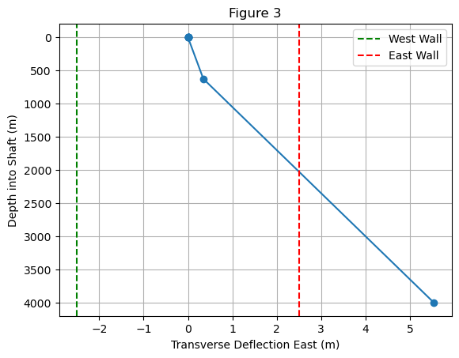

```python
def ode_coriolis(t, S):
    x, vx, y, vy = S # S = [x, vx, y, vy] where x is East, y is depth into shaft

    g_local = g0 * (y / R_earth) # y is distance from center. Fall direction is -y.

    # coriolis acceleration
    a_x = -2 * omega * vy
    a_y = -g_local + 2 * omega * vx

    return [vx, a_x, vy, a_y]

def hit_bottom_coriolis(t, S):
    return S[2] - (R_earth - shaft_depth)
hit_bottom_coriolis.terminal = True

sol_cor = solve_ivp(ode_coriolis, [0, 100], [0, 0, R_earth, 0], events=hit_bottom_coriolis)

fig3, ax = plt.subplots()
# Plot depth from surface vs transverse deflection
depth_fallen = R_earth - sol_cor.y[2]
ax.plot(sol_cor.y[0], depth_fallen, 'o-')
ax.axvline(-2.5, color='green', linestyle='--', label='West Wall')
ax.axvline(2.5, color='red', linestyle='--', label='East Wall')

ax.invert_yaxis() # 0 depth at top, 4000 at bottom
ax.set_xlabel('Transverse Deflection East (m)')
ax.set_ylabel('Depth into Shaft (m)')
ax.set_title('Figure 3')
ax.grid()
ax.legend()
```

The test mass bumps into the wall first.